[← Portfolio](https://cameron-batts.github.io/)

# Loan Default Classification with Cost-Sensitive Trees

**Author:** Cameron Batts

## Validation update - October 22, 2026

The corrected, training-only-resampled classification tree executed and rendered on 19,395 training and 9,696 untouched test rows. Default recall=98.60%, default precision=11.79%, specificity=8.02% and accuracy=18.06%. The high recall comes with many false positives; balanced accuracy is 53.31%. The all-nondefault baseline has 88.91% accuracy and zero default recall. These revised-workflow scores do not reproduce the archived preprocessing, and no deployment benefit is established.

[Aggregate validation record](https://github.com/Cameron-Batts/Loan-Default-Decision-Tree/blob/main/Reports/validation_results.json). [Executed R workflow](https://github.com/Cameron-Batts/Loan-Default-Decision-Tree/blob/main/Reports/executed_workflow.html) · [Recorded R environment](https://github.com/Cameron-Batts/Loan-Default-Decision-Tree/blob/main/Reports/validated_session.txt).

Run `Rscript validation/rerun_analysis.R` from the project root.

## Problem

Examine class imbalance, classification-tree pruning and explicit false-negative cost assumptions.

## Approach

Split by class before preprocessing, learn median fills on training rows, resample only training observations to a 2:1 nondefault/default ratio, explicitly fit a classification tree and prune at a fixed cp=0.002. Evaluate class-1 recall against an all-nondefault baseline.

## Reported results

The bundled dataset has 29,092 records, including 3,227 defaults (11.09%). The archived analysis illustrates a root-only initial tree and later tree structures, but reports no held-out classification metrics. Improved default detection has not been established.

## Limitations and corrections

Historical resampling used the full dataset after creating a split, and later rpart fits omitted method="class" while the response was numeric. This revision fixes both issues. Pruning uses the original fixed cp rather than claiming CV selection. Resampling changes prevalence and the 10:1 loss is illustrative. Training imputation precedes internal rpart CV, so its scores are not fully fold-isolated; final assessment uses the untouched test split.

## Verification

Dataset dimensions, missingness and relevant counts were checked directly. The revised R workflow was executed and rendered during this pass. Fresh revised-workflow metrics are reported separately from the archive; no operational benefit is claimed.

## Data

The included data have no documented upstream source or redistribution license in the original repository. Preserve provenance when it becomes available.

## Run

Install R and Pandoc (or use RStudio), then run from the repository root:

```r
source("install.R")
rmarkdown::render("Notebooks/loan_default_decision_tree.Rmd")
```

R package versions are recorded in Reports/validated_packages.csv and Reports/validated_session.txt.

## Files

- [R Markdown analysis](https://github.com/Cameron-Batts/Loan-Default-Decision-Tree/blob/main/Notebooks/loan_default_decision_tree.Rmd)
- [Readable report](https://github.com/Cameron-Batts/Loan-Default-Decision-Tree/blob/main/Reports/loan_default_decision_tree.html)
- [Original PDF](https://github.com/Cameron-Batts/Loan-Default-Decision-Tree/blob/main/Reports/Loan%20Default%20Prediction%20via%20Decision%20Trees.pdf) — historical export; conclusions may predate the corrections above.
- [Live portfolio report](https://cameron-batts.github.io/loan_default_decision_tree.html)

## Figures regenerated during validation

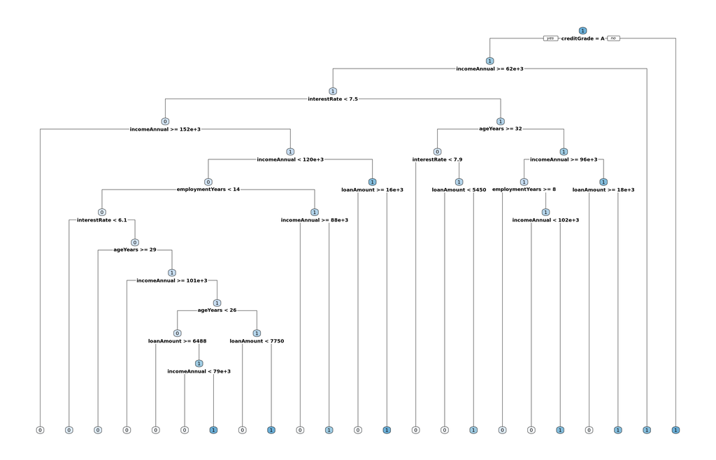